# Fantasy Football Analysis

Nolan Jolicoeur

12/6/2021

## Analysis Questions

Part 1

- Is there a correlation between fantasy points and wins?
- Is there a correlation between fantasy points and team points scored?
- Is there a correlation between team points allowed and fantasy points scored by position?

Part 2

- Which QB statistics have the highest correlation to fantasy points?
- Which RB statistics have the highest correlation to fantasy points?
- Which WR/TE statistics have the highest correlation to fantasy points?

### Now Load Libraries

```r
library(dplyr)
```

```r
library(ggplot2)
library(sqldf)
library(RSQLite)
library(devtools)
library(ggpubr)
library(tidyverse)
```

## Rules of Fantasy Football

### Summary of how fantasy football works

People draft teams from a pool of real NFL players. Points are gained on a weekly basis depending on how players perform. For this project I chose to use Draft Kings scoring system because it is the most popular and is considered the standard system.

Point System:

Passing:

- Touchdown = 4points
- Yard = 0.04 points

  Running:
- Touchdown = 6 points
- Yard = 0.1 points

  Receiving:
- Touchdown = 6 points
- Yard = 0.1 points
- Catch = 1 points

  Fantasy team consist of quarterbacks, running backs, and wide receivers. In this project I tested the strength of the relationships between different statistics and fantasy points. We want to find which fantasy football stats matter the most and which calculated stats might also relate to fantasy points. We also can sum up the fantasy points for all the NFL teams to find out if fantasy football success relates to actual team success. There will be 2 parts to this project. Part 1 is team based stats and part 2 is a more specific dive into stats by position group.

### For more details read the links below:

- https://www.nfl.com/news/how-to-play-fantasy-football-a-beginner-s-guide-0ap3000000692955
- https://www.nola.com/sports/betting/fantasy/article_61d50a44-0528-11ec-892d-0f47623dbc0d.html

### Data Upload:

```r
#Data is through November 29, 2021
df <- read.csv("~/Downloads/nfl_pass_rush_receive_raw_data (1).csv")
```

### Creating Team Data Frame:

- First I have to create a data frame of team records in order to do the first part.
- I could not take one from the internet because it had to much the other data I imported and the ones on the internet update weekly.

```r
team = c("ARI", "ATL", "BAL", "BUF", "CAR", "CHI", "CIN", "CLE", "DAL", "DEN", "DET", "GNB", "HOU", "IND", "JAX", "KAN", "LVR", "LAC", "LAR", "MIA", "MIN", "NWE", "NOR", "NYG", "NYJ", "PHI", "PIT", "SFO", "SEA", "TAM", "TEN", "WAS")
wins = c(9,5,8,7,5,4,7,6,7,6,0,9,2,6,2,7,6,6,7,5,5,8,5,4,3,5,5,6,3,8,8,5)
losses = c(2,6,3,4,7,7,4,6,4,5,10,3,9,6,9,4,5,5,4,7,6,4,6,7,8,7,5,5,8,3,4,6)
ties = c(0,0,0,0,0,0,0,0,0,0,1,0,0,0,0,0,0,0,0,0,0,0,0,0,0,0,1,0,0,0,0,0)
points_for = c(310,199,263,326,236,179,309,254,326,228,174,283,164,340,173,281,259,273,299,234,281,336,257,202,199,304,224,280,209,347,304,229)
points_against = c(202,302,240,182,253,254,226,267,250,196,289,242,292,283,283,250,295,293,263,279,276,190,249,253,334,273,267,248,226,253,290,282)
team_records = data.frame(team, wins, losses, ties, points_for, points_against)
```

### Organize Data with SQL:

- Next I use SQL to organize the data and combine data sets using the ‘team’ column for a left join.
- This will allow me to compare team records and points to fantasy points.

```r
Fantasy_PTS_By_Team = sqldf("select team, sum(Total_DKP)
                            from df
                            group by team")
Fantasy_PTS_By_Team = rename(Fantasy_PTS_By_Team, 'Total_DKP' = 'sum(Total_DKP)')
Combined_Team_Stats = sqldf("select team_records.team, team_records.wins,
                            team_records.losses, team_records.ties, team_records.points_for,                               team_records.points_against, Fantasy_PTS_By_Team.Total_DKP
                            from team_records
                            left join Fantasy_PTS_By_Team on
                            team_records.team = Fantasy_PTS_By_Team.team")
Fantasy_PTS_Against_Team = sqldf("select Opponent_abbrev, sum(Total_DKP)
                                 from df
                                 group by Opponent_abbrev")
Fantasy_PTS_Against_Team = rename(Fantasy_PTS_Against_Team, 'Total_DKP' = 'sum(Total_DKP)')
Fantasy_PTS_Against_Team = rename(Fantasy_PTS_Against_Team, 'team' = 'Opponent_abbrev')
Combined_Points_Against = sqldf("select team_records.team, team_records.wins,
                                team_records.losses, team_records.ties, team_records.points_for                                 , team_records.points_against, Fantasy_PTS_Against_Team                                        .Total_DKP
                                from team_records
                                left join Fantasy_PTS_Against_Team on team_records.team =                                      Fantasy_PTS_Against_Team.team")
```

### Graphs, Correlations, and Summaries for Team Stats:

- This is a set of graphs, correlations, and summaries for the team statistics that I am comparing.

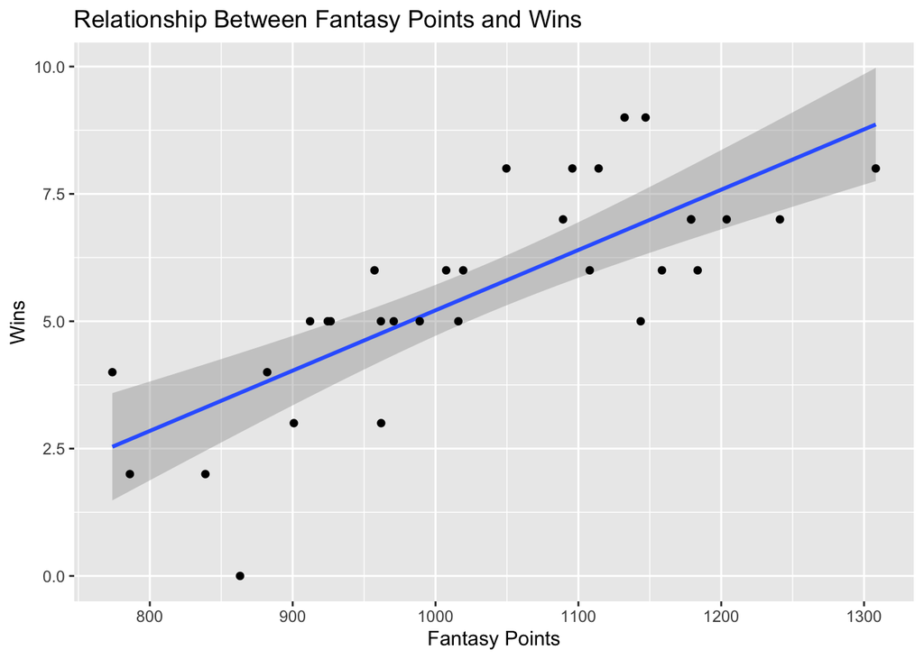

```r
Points_Per_Win <- ggplot(Combined_Team_Stats, aes(x = Total_DKP, y = wins))+
  geom_smooth(method = "lm", se = TRUE)+
  labs(title = "Relationship Between Fantasy Points and Wins", x = "Fantasy Points", y = "Wins")+
  geom_point()
Points_Per_Win
```

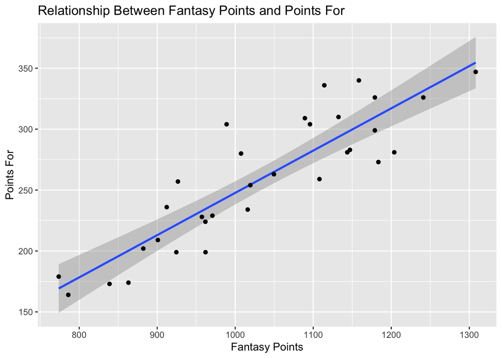

```r
Fantasy_PTS_Per_Actual_Point <- ggplot(Combined_Team_Stats, aes(x = Total_DKP, y = points_for))+
  geom_smooth(method = "lm", se = TRUE)+
  labs(title = "Relationship Between Fantasy Points and Points For", x = "Fantasy Points", y = "Points For")+
  geom_point()
Fantasy_PTS_Per_Actual_Point
```

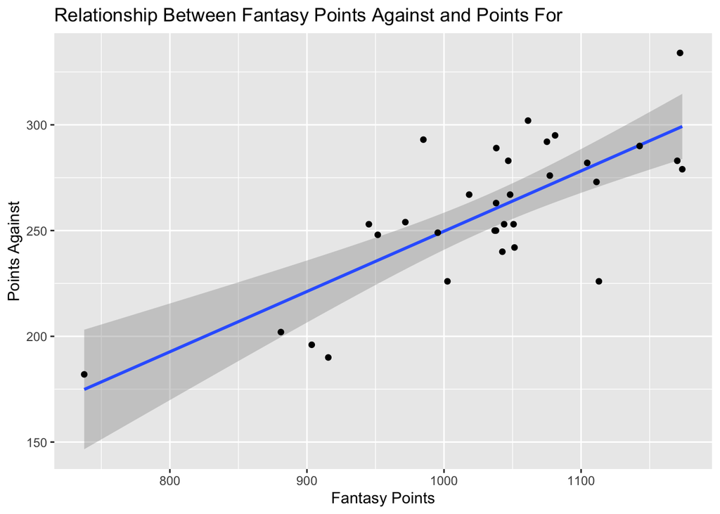

```r
Fantasy_PTS_Per_Point_Against <- ggplot(Combined_Points_Against, aes(x = Total_DKP, y = points_against))+
  geom_smooth(method = "lm", se = TRUE)+
  labs(title = "Relationship Between Fantasy Points Against and Points For", x = "Fantasy Points", y = "Points Against")+
  geom_point()
Fantasy_PTS_Per_Point_Against
```

```r
cor_wins = cor.test(Combined_Team_Stats$Total_DKP, Combined_Team_Stats$wins, method = "pearson")
cor_wins
```

```
##
##  Pearson's product-moment correlation
##
## data:  Combined_Team_Stats$Total_DKP and Combined_Team_Stats$wins
## t = 6.6849, df = 30, p-value = 2.092e-07
## alternative hypothesis: true correlation is not equal to 0
## 95 percent confidence interval:
##  0.5817269 0.8838251
## sample estimates:
##       cor
## 0.7735171
```

```r
model_wins = lm(points_for~Total_DKP, Combined_Team_Stats)
summary(model_wins)
```

```
##
## Call:
## lm(formula = points_for ~ Total_DKP, data = Combined_Team_Stats)
##
## Residuals:
##     Min      1Q  Median      3Q     Max
## -38.366 -17.102  -5.118  16.970  60.128
##
## Coefficients:
##              Estimate Std. Error t value Pr(>|t|)
## (Intercept) -99.20128   35.03917  -2.831   0.0082 **
## Total_DKP     0.34691    0.03367  10.304 2.27e-11 ***
## ---
## Signif. codes:  0 '***' 0.001 '**' 0.01 '*' 0.05 '.' 0.1 ' ' 1
##
## Residual standard error: 25.63 on 30 degrees of freedom
## Multiple R-squared:  0.7797, Adjusted R-squared:  0.7723
## F-statistic: 106.2 on 1 and 30 DF,  p-value: 2.267e-11
```

### Linear Model for Fantasy Points and Team Wins:

- y = 0.0118x - 6.6243, R-Squared = 0.5849 (Good)

```r
cor_points_for = cor.test(Combined_Team_Stats$Total_DKP, Combined_Team_Stats$points_for, method = "pearson")
cor_points_for
```

```
##
##  Pearson's product-moment correlation
##
## data:  Combined_Team_Stats$Total_DKP and Combined_Team_Stats$points_for
## t = 10.304, df = 30, p-value = 2.267e-11
## alternative hypothesis: true correlation is not equal to 0
## 95 percent confidence interval:
##  0.7720058 0.9417371
## sample estimates:
##       cor
## 0.8830013
```

```r
model_points_for = lm(wins~Total_DKP, Combined_Team_Stats)
summary(model_points_for)
```

```
##
## Call:
## lm(formula = wins ~ Total_DKP, data = Combined_Team_Stats)
##
## Residuals:
##     Min      1Q  Median      3Q     Max
## -3.5947 -0.9079  0.0239  0.7526  2.2182
##
## Coefficients:
##              Estimate Std. Error t value Pr(>|t|)
## (Intercept) -6.624356   1.843185  -3.594  0.00115 **
## Total_DKP    0.011839   0.001771   6.685 2.09e-07 ***
## ---
## Signif. codes:  0 '***' 0.001 '**' 0.01 '*' 0.05 '.' 0.1 ' ' 1
##
## Residual standard error: 1.348 on 30 degrees of freedom
## Multiple R-squared:  0.5983, Adjusted R-squared:  0.5849
## F-statistic: 44.69 on 1 and 30 DF,  p-value: 2.092e-07
```

### Linear Model for Fantasy Points and Team Points For:

- y = 0.3469x - 99.2013, R-Squared = 0.7723 (Very Good)

```r
cor_points_against = cor.test(Combined_Points_Against$Total_DKP, Combined_Points_Against$points_against, method = "pearson")
cor_points_against
```

```
##
##  Pearson's product-moment correlation
##
## data:  Combined_Points_Against$Total_DKP and Combined_Points_Against$points_against
## t = 6.3442, df = 30, p-value = 5.349e-07
## alternative hypothesis: true correlation is not equal to 0
## 95 percent confidence interval:
##  0.5546285 0.8747487
## sample estimates:
##       cor
## 0.7569346
```

```r
model_points_against = lm(points_against~Total_DKP, Combined_Points_Against)
summary(model_points_against)
```

```
##
## Call:
## lm(formula = points_against ~ Total_DKP, data = Combined_Points_Against)
##
## Residuals:
##     Min      1Q  Median      3Q     Max
## -55.896 -14.128   1.545  14.001  47.603
##
## Coefficients:
##              Estimate Std. Error t value Pr(>|t|)
## (Intercept) -35.32768   46.53972  -0.759    0.454
## Total_DKP     0.28502    0.04493   6.344 5.35e-07 ***
## ---
## Signif. codes:  0 '***' 0.001 '**' 0.01 '*' 0.05 '.' 0.1 ' ' 1
##
## Residual standard error: 22.9 on 30 degrees of freedom
## Multiple R-squared:  0.573,  Adjusted R-squared:  0.5587
## F-statistic: 40.25 on 1 and 30 DF,  p-value: 5.349e-07
```

### Linear Model for Fantasy Points and Team Points Against:

- y = 0.2850x - 35.3277, R-Squared = 0.5587 (Average)

```r
row_names <- c("Wins", "Points For", "Points Against")
team_values <- c(cor_wins$estimate, cor_points_for$estimate, cor_points_against$estimate)
team_table = data.frame(row_names, team_values)
team_table = team_table[order(team_table$team_values, decreasing = TRUE),]
print(team_table)
```

```
##        row_names team_values
## 2     Points For   0.8830013
## 1           Wins   0.7735171
## 3 Points Against   0.7569346
```

### Now Compare Opponents Defense to Fantasy Points by Position:

- Now I am going to compare how the opponents defense affects fantasy points by position
- I will do this by extracting the 5 best and 5 worst fantasy defenses and seeing how many points were scored against them on average by position group.

```r
worst_teams = team_records[order(points_against),]
bottom_ten = tail(worst_teams, 5)
bottom_ten_teams = bottom_ten$team
bottom_ten_teams_df = as.data.frame(bottom_ten_teams)
Vs_bottom_ten = sqldf("select df.pos, df.pass_att, df.rush_att, df.rec, df.team, df                                     .Opponent_abbrev, df.Total_DKP, bottom_ten_teams_df.bottom_ten_teams
                         from df
                         left join bottom_ten_teams_df on df.Opponent_abbrev =                                          bottom_ten_teams_df.bottom_ten_teams")
Vs_bottom_ten = Vs_bottom_ten[complete.cases(Vs_bottom_ten),]

QB_vs_bottom_ten = sqldf("select pos, avg(Total_DKP)
                         from Vs_bottom_ten
                         where pass_att >= 10 and pos = 'QB'")
RB_vs_bottom_ten = sqldf("select pos, avg(Total_DKP)
                         from Vs_bottom_ten
                         where rush_att >= 5 and pos = 'RB'")
WR_TE_vs_bottom_ten = sqldf("select pos, avg(Total_DKP)
                         from Vs_bottom_ten
                         where rec >= 3 and pos ='WR' or pos ='TE'")

top_ten = head(worst_teams, 5)
top_ten_teams = top_ten$team
top_ten_teams_df = as.data.frame(top_ten_teams)
Vs_top_ten = sqldf("select df.pos, df.team, df.Opponent_abbrev, df.pass_att, df.rush_att, df                            .rec, df.Total_DKP, top_ten_teams_df.top_ten_teams
                         from df
                         left join top_ten_teams_df on df.Opponent_abbrev = top_ten_teams_df                            .top_ten_teams")
Vs_top_ten = Vs_top_ten[complete.cases(Vs_top_ten),]
QB_vs_top_ten = sqldf("select pos, avg(Total_DKP)
                         from Vs_top_ten
                         where pass_att >= 10 and pos = 'QB'")
RB_vs_top_ten = sqldf("select pos, avg(Total_DKP)
                         from Vs_top_ten
                         where rush_att >= 5 and pos = 'RB'")
WR_TE_vs_top_ten = sqldf("select pos, avg(Total_DKP)
                         from Vs_top_ten
                         where rec >= 3 and pos ='WR' or pos ='TE'")

Vs_Top_Teams = c(QB_vs_top_ten$`avg(Total_DKP)`, RB_vs_top_ten$`avg(Total_DKP)`, WR_TE_vs_top_ten$`avg(Total_DKP)`)
Vs_Worst_Teams = c(QB_vs_bottom_ten$`avg(Total_DKP)`, RB_vs_bottom_ten$`avg(Total_DKP)`, WR_TE_vs_bottom_ten$`avg(Total_DKP)`)
row_names4 = c("QB Fantasy Points", "RB Fantasy Points", "WR/TE Fantasy Points")
positional_top_table = as.data.frame(Vs_Top_Teams,row_names4)
positional_worst_table = as.data.frame(Vs_Worst_Teams, row_names4)
knitr::kable(list(positional_top_table,positional_worst_table))
```

|  | Vs_Top_Teams |
| --- | --- |
| QB Fantasy Points | 13.930000 |
| RB Fantasy Points | 12.896296 |
| WR/TE Fantasy Points | 6.767038 |

|  | Vs_Worst_Teams |
| --- | --- |
| QB Fantasy Points | 18.918909 |
| RB Fantasy Points | 13.575810 |
| WR/TE Fantasy Points | 8.377643 |

## Part 1 conclusion:

- Fantasy points does relate to wins but has a stronger relationship to points scored than wins.
- On average, players do put up more fantasy points when playing against bottom 5 teams vs top 5 teams as far as points allowed.
- There is a correlation between team success and fantasy points.

### Next I will organize the data by position starting with QB and Begin Part 2:

```r
QB_df1 <- sqldf("select pos, player, team, pass_cmp, pass_att, pass_yds, pass_td, pass_int,                 pass_sacked, pass_sacked_yds, pass_long, pass_rating, comb_pass_rush_play,                     rush_scrambles, comb_pass_play, comb_rush_play, pass_poor_throws, pass_blitzed,                pass_hurried, Total_DKP
             from df
             where pos = 'QB' and pass_att > 15")
QB_totals = sqldf("select pos, player, team, avg(pass_cmp), avg(pass_att), avg(pass_yds),
                 avg (pass_td), avg(pass_int), avg(pass_sacked), avg(pass_long),
                 avg(pass_rating), avg(rush_scrambles), avg(comb_pass_play),
                 avg(comb_rush_play), avg(pass_poor_throws), avg(pass_blitzed),
                 avg(pass_hurried), avg(Total_DKP)
                 from QB_df1
                 group by player")
```

- pass_att must be greater than 15 because we are trying to exclude QB’s who were subbed into the end of a game that was a blowout.
- They will be automatic outliers and will skew the data.

### Now we must rename the columns so we can use them in SQL:

```r
QB_totals = rename(QB_totals, 'AVG_Cmp' = 'avg(pass_cmp)')
QB_totals = rename(QB_totals, 'AVG_Pass_Att' = 'avg(pass_att)')
QB_totals = rename(QB_totals, 'AVG_Pass_Yards' = 'avg(pass_yds)')
QB_totals = rename(QB_totals, 'AVG_Pass_TD' = 'avg (pass_td)')
QB_totals = rename(QB_totals, 'AVG_Pass_Sacked' = 'avg(pass_sacked)')
QB_totals = rename(QB_totals, 'AVG_Pass_Long' = 'avg(pass_long)')
QB_totals = rename(QB_totals, 'AVG_Pass_Rating' = 'avg(pass_rating)')
QB_totals = rename(QB_totals, 'AVG_INT' = 'avg(pass_int)')
QB_totals = rename(QB_totals, 'AVG_Pass_Play' = 'avg(comb_pass_play)')
QB_totals = rename(QB_totals, 'AVG_Rush_Play' = 'avg(comb_rush_play)')
QB_totals = rename(QB_totals, 'AVG_Poor_Passes' = 'avg(pass_poor_throws)')
QB_totals = rename(QB_totals, 'AVG_Blitzed' = 'avg(pass_blitzed)')
QB_totals = rename(QB_totals, 'AVG_Hurried' = 'avg(pass_hurried)')
QB_totals = rename(QB_totals, 'AVG_Total_DKP' = 'avg(Total_DKP)')
```

### Now I am Going to Graph Each QB Statistic in Relation to Fantasy Points:

- I have decided to only display the graphs that have the strongest relationships.

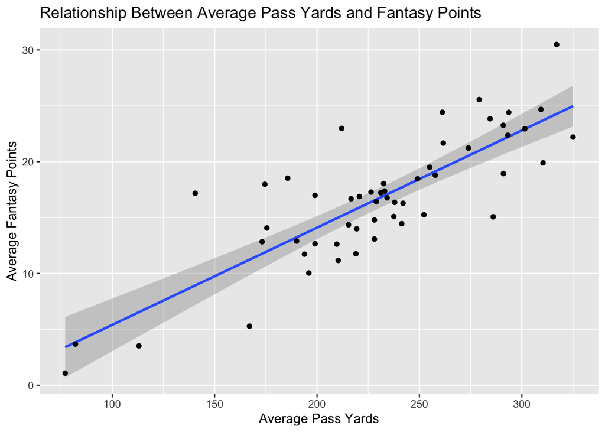

```r
pass_cmp <- ggplot(QB_totals, aes(x = AVG_Cmp, y = AVG_Total_DKP))+
  geom_smooth(method = "lm", se = TRUE)+
  labs(title = "Relationship Between Average Pass Completions and Average Fantasy Points", x = "Average Pass Completions", y = "Average Fantasy Points")+
  geom_point()


pass_att <- ggplot(QB_totals, aes(x = AVG_Pass_Att, y = AVG_Total_DKP))+
  geom_smooth(method = "lm", se = TRUE)+
  labs(title = "Relationship Between Average Pass Attempts and Fantasy Points", x = "Average Pass Attempts", y = "Average Fantasy Points")+
  geom_point()


pass_yds <- ggplot(QB_totals, aes(x = AVG_Pass_Yards, y = AVG_Total_DKP))+
  geom_smooth(method = "lm", se = TRUE)+
  labs(title = "Relationship Between Average Pass Yards and Fantasy Points", x = "Average Pass Yards", y = "Average Fantasy Points")+
  geom_point()
pass_yds
```

[figure not shown]

```r
pass_td <- ggplot(QB_totals, aes(x = AVG_Pass_TD, y = AVG_Total_DKP))+
  geom_smooth(method = "lm", se = TRUE)+
  labs(title = "Relationship Between Pass Attempts and Fantasy Points", x = "Average Pass Attempts", y = "Average Fantasy Points")+
  geom_point()
pass_td
```

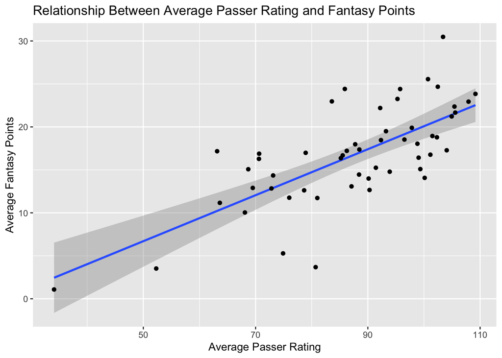

```r
pass_sacked <- ggplot(QB_totals, aes(x = AVG_Pass_Sacked, y = AVG_Total_DKP))+
  geom_smooth(method = "lm", se = TRUE)+
  labs(title = "Relationship Between Average Times Sacked and Fantasy Points", x = "Average Times Sacked", y = "Average Fantasy Points")+
  geom_point()

pass_long <- ggplot(QB_totals, aes(x = AVG_Pass_Long, y = AVG_Total_DKP))+
  geom_smooth(method = "lm", se = TRUE)+
  labs(title = "Relationship Between Average Longest Pass and Fantasy Points", x = "Average Longest Pass", y = "Average Fantasy Points")+
  geom_point()

pass_rating <- ggplot(QB_totals, aes(x = AVG_Pass_Rating, y = AVG_Total_DKP))+
  geom_smooth(method = "lm", se = TRUE)+
  labs(title = "Relationship Between Average Passer Rating and Fantasy Points", x = "Average Passer Rating", y = "Average Fantasy Points")+
  geom_point()
pass_rating
```

```r
comb_pass_play <- ggplot(QB_totals, aes(x = AVG_Pass_Play, y = AVG_Total_DKP))+
  geom_smooth(method = "lm", se = TRUE)+
  labs(title = "Relationship Between Average Number of Pass Plays and Fantasy Points", x = "Average Number of Pass Plays", y = "Average Fantasy Points")+
  geom_point()

comb_rush_play <- ggplot(QB_totals, aes(x = AVG_Rush_Play, y = AVG_Total_DKP))+
  geom_smooth(method = "lm", se = TRUE)+
  labs(title = "Relationship Between Average Number of Run Plays and Fantasy Points", x = "Average Number of Run Plays", y = "Average Fantasy Points")+
  geom_point()

poor_passes <- ggplot(QB_totals, aes(x = AVG_Poor_Passes, y = AVG_Total_DKP))+
  geom_smooth(method = "lm", se = TRUE)+
  labs(title = "Relationship Between Average Poor Passes and Fantasy Points", x = "Average Poor Passes", y = "Average Fantasy Points")+
  geom_point()

pass_blitzed <- ggplot(QB_totals, aes(x = AVG_Blitzed, y = AVG_Total_DKP))+
  geom_smooth(method = "lm", se = TRUE)+
  labs(title = "Relationship Between Average Passes Blitzed and Fantasy Points", x = "Average Passes Blitzed", y = "Average Fantasy Points")+
  geom_point()

pass_hurried <- ggplot(QB_totals, aes(x = AVG_Hurried, y = AVG_Total_DKP))+
  geom_smooth(method = "lm", se = TRUE)+
  labs(title = "Relationship Between Average Passes Hurried and Fantasy Points", x = "Average Passes Hurried", y = "Average Fantasy Points")+
  geom_point()
```

### Next I will Create a Function to Calculate Correlation Quicker:

```r
corr <- function(x,y)
  cor.test(x,y,method='pearson')
```

### Next I will Find the Correlation Between Each Statistic and Fantasy Points and Create a Table:

```r
cor_avg_cmp = corr(QB_totals$AVG_Cmp,QB_totals$AVG_Total_DKP)

cor_avg_pass_att = corr(QB_totals$AVG_Pass_Att,QB_totals$AVG_Total_DKP)

cor_avg_pass_yds = corr(QB_totals$AVG_Pass_Yards,QB_totals$AVG_Total_DKP)

cor_avg_pass_td = corr(QB_totals$AVG_Pass_TD,QB_totals$AVG_Total_DKP)

cor_avg_pass_sacked = corr(QB_totals$AVG_Pass_Sacked,QB_totals$AVG_Total_DKP)

cor_avg_pass_long = corr(QB_totals$AVG_Pass_Long,QB_totals$AVG_Total_DKP)

cor_avg_pass_rating = corr(QB_totals$AVG_Pass_Rating,QB_totals$AVG_Total_DKP)

cor_avg_pass_int = corr(QB_totals$AVG_INT,QB_totals$AVG_Total_DKP)

cor_avg_pass_play = corr(QB_totals$AVG_Pass_Play,QB_totals$AVG_Total_DKP)

cor_avg_rush_play = corr(QB_totals$AVG_Rush_Play,QB_totals$AVG_Total_DKP)

cor_avg_poor_pass = corr(QB_totals$AVG_Poor_Passes,QB_totals$AVG_Total_DKP)

cor_avg_blitzed = corr(QB_totals$AVG_Blitzed,QB_totals$AVG_Total_DKP)

cor_avg_pass_hurried = corr(QB_totals$AVG_Hurried,QB_totals$AVG_Total_DKP)

QB_values = c(cor_avg_pass_att$estimate, cor_avg_cmp$estimate, cor_avg_pass_yds$estimate, cor_avg_pass_td$estimate, cor_avg_pass_sacked$estimate, cor_avg_pass_long$estimate, cor_avg_pass_rating$estimate, cor_avg_pass_int$estimate, cor_avg_pass_play$estimate, cor_avg_rush_play$estimate, cor_avg_poor_pass$estimate, cor_avg_blitzed$estimate, cor_avg_pass_hurried$estimate)
row_names2 = c("Average Attempts", "Average Completions", "Average Passing Yards", "Average Passing Touchdowns", "Average Times Sacked", "Average Longest Pass", "Average Passer Rating", "Average Interceptions", "Average Passing Plays", "Average Rushing Plays", "Average Poor Passes", "Average Times Blitzed", "Average Passes Hurried")
QB_table = data.frame(row_names2, QB_values)
QB_table = QB_table[order(QB_table$QB_values, decreasing = TRUE),]
QB_table
```

```
##                    row_names2    QB_values
## 4  Average Passing Touchdowns  0.887081580
## 3       Average Passing Yards  0.825130809
## 7       Average Passer Rating  0.713660641
## 9       Average Passing Plays  0.626841441
## 1            Average Attempts  0.577609660
## 2         Average Completions  0.551552568
## 6        Average Longest Pass  0.487832083
## 10      Average Rushing Plays  0.302522184
## 11        Average Poor Passes  0.295717554
## 5        Average Times Sacked  0.103122367
## 13     Average Passes Hurried  0.053889982
## 12      Average Times Blitzed -0.009947472
## 8       Average Interceptions -0.149726553
```

### I Will Now Model the Stats With the Highest Correlations to Fantasy Points:

```r
model_pass_yds = lm(AVG_Total_DKP~AVG_Pass_Yards, QB_totals)
summary(model_pass_yds)
```

```
##
## Call:
## lm(formula = AVG_Total_DKP ~ AVG_Pass_Yards, data = QB_totals)
##
## Residuals:
##     Min      1Q  Median      3Q     Max
## -6.5063 -2.3218 -0.1601  1.1393  8.2428
##
## Coefficients:
##                 Estimate Std. Error t value Pr(>|t|)
## (Intercept)    -3.290576   1.968680  -1.671    0.101
## AVG_Pass_Yards  0.086959   0.008337  10.430 3.01e-14 ***
## ---
## Signif. codes:  0 '***' 0.001 '**' 0.01 '*' 0.05 '.' 0.1 ' ' 1
##
## Residual standard error: 3.283 on 51 degrees of freedom
## Multiple R-squared:  0.6808, Adjusted R-squared:  0.6746
## F-statistic: 108.8 on 1 and 51 DF,  p-value: 3.006e-14
```

### This is the Linear Model for Passing Yards and Fantasy Points:

- y = 0.0869x + -3.291, R-Squared = 0.6746 (Above Average)

```r
model_pass_td = lm(AVG_Total_DKP~AVG_Pass_TD, QB_totals)
summary(model_pass_td)
```

```
##
## Call:
## lm(formula = AVG_Total_DKP ~ AVG_Pass_TD, data = QB_totals)
##
## Residuals:
##    Min     1Q Median     3Q    Max
## -5.886 -1.685 -0.411  1.740  7.455
##
## Coefficients:
##             Estimate Std. Error t value Pr(>|t|)
## (Intercept)   6.9655     0.7992   8.716 1.13e-11 ***
## AVG_Pass_TD   7.2347     0.5272  13.724  < 2e-16 ***
## ---
## Signif. codes:  0 '***' 0.001 '**' 0.01 '*' 0.05 '.' 0.1 ' ' 1
##
## Residual standard error: 2.683 on 51 degrees of freedom
## Multiple R-squared:  0.7869, Adjusted R-squared:  0.7827
## F-statistic: 188.3 on 1 and 51 DF,  p-value: < 2.2e-16
```

### This is the Linear Model for Passing Touchdowns and Fantasy Points:

- Passing touchdowns have a higher correlation than passing yards even though they are both calculated into fantasy points.
- y = 7.2347x + 6.9655, R-Squared = 0.7827 (Good)

```r
model_pass_rating = lm(AVG_Total_DKP~AVG_Pass_Rating, QB_totals)
summary(model_pass_rating)
```

```
##
## Call:
## lm(formula = AVG_Total_DKP ~ AVG_Pass_Rating, data = QB_totals)
##
## Residuals:
##      Min       1Q   Median       3Q      Max
## -11.2360  -2.5392   0.2442   1.4613   9.4898
##
## Coefficients:
##                 Estimate Std. Error t value Pr(>|t|)
## (Intercept)     -6.67816    3.26116  -2.048   0.0457 *
## AVG_Pass_Rating  0.26759    0.03678   7.276    2e-09 ***
## ---
## Signif. codes:  0 '***' 0.001 '**' 0.01 '*' 0.05 '.' 0.1 ' ' 1
##
## Residual standard error: 4.071 on 51 degrees of freedom
## Multiple R-squared:  0.5093, Adjusted R-squared:  0.4997
## F-statistic: 52.94 on 1 and 51 DF,  p-value: 1.998e-09
```

### This is the Linear Model for Passer Rating and Fantasy Points:

- This stat gives the best model out of stats not calculated into fantasy points.
- y = 0.2676x -6.6782 R-Squared = 0.4997 (Average)

### Next I Will Move Onto RB’s and Create a Data Frame for their Statistics:

```r
RB_df1 = sqldf("select pos, player, team, rush_att, rush_yds, rush_td, rush_long, targets, rec,           rec_yds, rec_td, rec_long, fumbles_lost, designed_rush_att, rush_yds_before_contact,           rush_yac, rush_broken_tackles, Total_DKP
          from df
          where pos = 'RB'")
RB_totals = sqldf("select pos, player, team, avg(rush_att), avg(rush_yds), avg(rush_td),
                  avg(rush_long), avg(targets), avg(rec), avg(rec_yds), avg(rec_td),
                  avg(rec_long), avg(fumbles_lost), avg(designed_rush_att),
                  avg(rush_yds_before_contact), avg(rush_yac), avg(rush_broken_tackles),
                  avg(Total_DKP)
                  from RB_df1
                  where rush_att > 5
                  group by player")
```

### Now I Must Rename All The Columns so I Can Use Them in SQL:

```r
RB_totals = rename(RB_totals, 'AVG_Total_DKP' = 'avg(Total_DKP)')
RB_totals = rename(RB_totals, 'AVG_Rush_Att' = 'avg(rush_att)')
RB_totals = rename(RB_totals, 'AVG_Rush_Yds' = 'avg(rush_yds)')
RB_totals = rename(RB_totals, 'AVG_Rush_TD' = 'avg(rush_td)')
RB_totals = rename(RB_totals, 'AVG_Rush_Long' = 'avg(rush_long)')
RB_totals = rename(RB_totals, 'AVG_Targets' = 'avg(targets)')
RB_totals = rename(RB_totals, 'AVG_Rec' = 'avg(rec)')
RB_totals = rename(RB_totals, 'AVG_Receiving_Yards' = 'avg(rec_yds)')
RB_totals = rename(RB_totals, 'AVG_Yds_Before_Contact' = 'avg(rush_yds_before_contact)')
RB_totals = rename(RB_totals, 'AVG_Yds_After_Contact' = 'avg(rush_yac)')
RB_totals = rename(RB_totals, 'AVG_Receiving_TD' = 'avg(rec_td)')
RB_totals = rename(RB_totals, 'AVG_Broken_Tackles' = 'avg(rush_broken_tackles)')
```

### Now I Will Create a Graph for Each Stat in Relation to Fantasy Points:

- I only display the graphs with the strongest relationship.

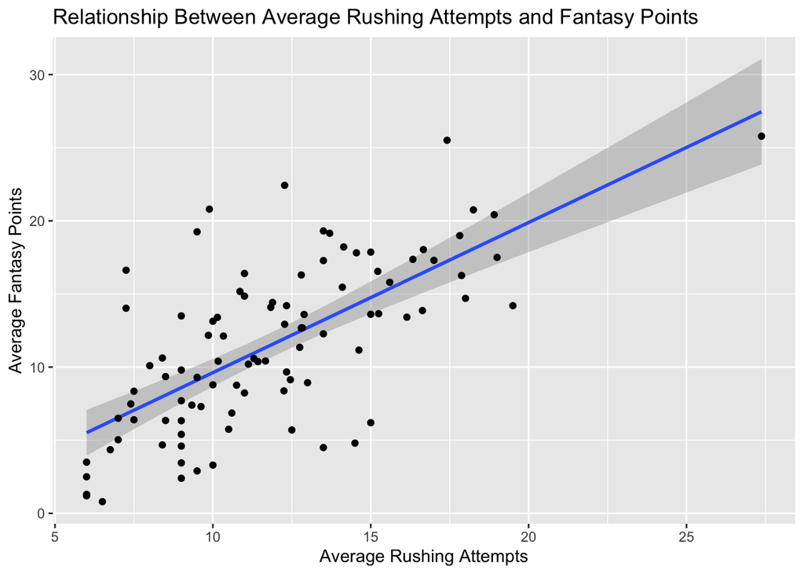

```r
RB_rush_att <- ggplot(RB_totals, aes(x = AVG_Rush_Att, y = AVG_Total_DKP))+
  geom_smooth(method = "lm", se = TRUE)+
  labs(title = "Relationship Between Average Rushing Attempts and Fantasy Points", x = "Average Rushing Attempts", y = "Average Fantasy Points")+
  geom_point()
RB_rush_att
```

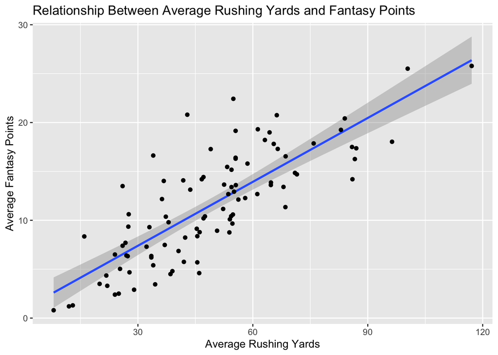

```r
RB_rush_yds <- ggplot(RB_totals, aes(x = AVG_Rush_Yds, y = AVG_Total_DKP))+
  geom_smooth(method = "lm", se = TRUE)+
  labs(title = "Relationship Between Average Rushing Yards and Fantasy Points", x = "Average Rushing Yards", y = "Average Fantasy Points")+
  geom_point()
RB_rush_yds
```

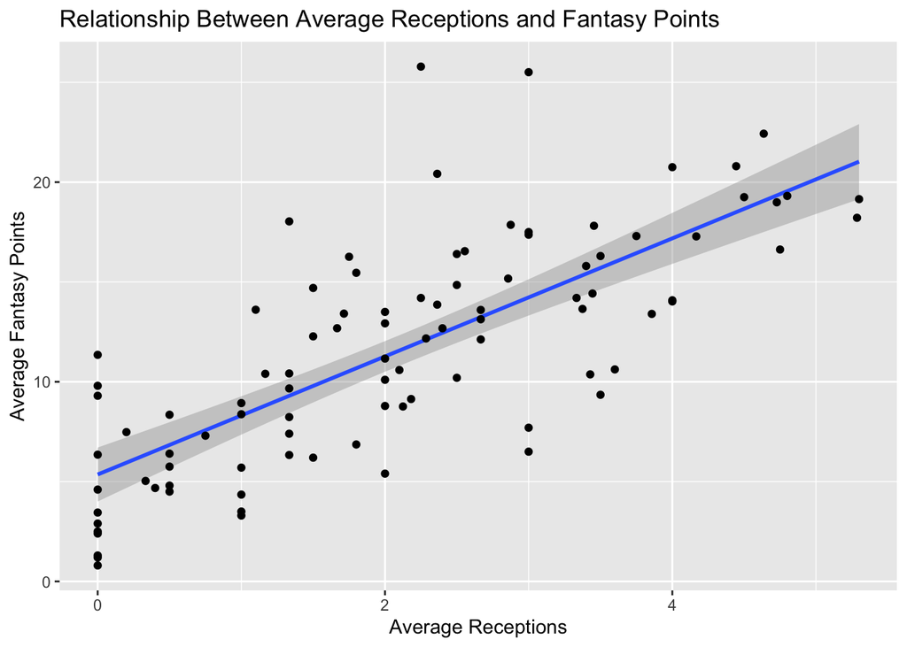

```r
RB_rush_td <- ggplot(RB_totals, aes(x = AVG_Rush_TD, y = AVG_Total_DKP))+
  geom_smooth(method = "lm", se = TRUE)+
  labs(title = "Relationship Between Average Rushing Touchdowns and Fantasy Points", x = "Average Rushing Touchdowns", y = "Average Fantasy Points")+
  geom_point()


RB_rush_long <- ggplot(RB_totals, aes(x = AVG_Rush_Long, y = AVG_Total_DKP))+
  geom_smooth(method = "lm", se = TRUE)+
  labs(title = "Relationship Between Average Longest Run and Fantasy Points", x = "Average Longest Run", y = "Average Fantasy Points")+
  geom_point()


RB_targets <- ggplot(RB_totals, aes(x = AVG_Targets, y = AVG_Total_DKP))+
  geom_smooth(method = "lm", se = TRUE)+
  labs(title = "Relationship Between Average Targets and Fantasy Points", x = "Average Targets", y = "Average Fantasy Points")+
  geom_point()


RB_rec <- ggplot(RB_totals, aes(x = AVG_Rec, y = AVG_Total_DKP))+
  geom_smooth(method = "lm", se = TRUE)+
  labs(title = "Relationship Between Average Receptions and Fantasy Points", x = "Average Receptions", y = "Average Fantasy Points")+
  geom_point()
RB_rec
```

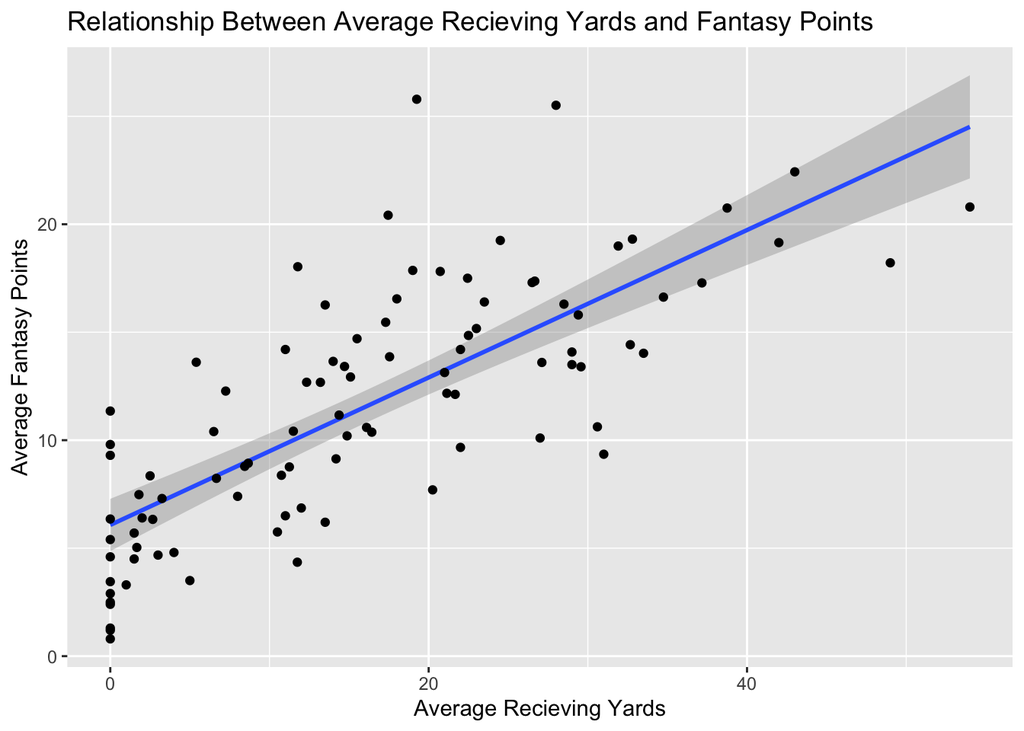

```r
RB_recieving_yds <- ggplot(RB_totals, aes(x = AVG_Receiving_Yards, y = AVG_Total_DKP))+
  geom_smooth(method = "lm", se = TRUE)+
  labs(title = "Relationship Between Average Recieving Yards and Fantasy Points", x = "Average Recieving Yards", y = "Average Fantasy Points")+
  geom_point()
RB_recieving_yds
```

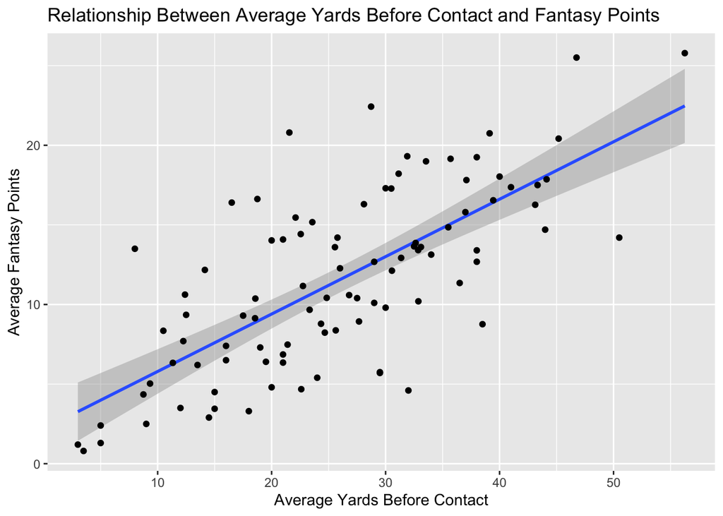

```r
RB_recieving_td <- ggplot(RB_totals, aes(x = AVG_Receiving_TD, y = AVG_Total_DKP))+
  geom_smooth(method = "lm", se = TRUE)+
  labs(title = "Relationship Between Average Recieving Touchdowns and Fantasy Points", x = "Average Recieving Touchdowns", y = "Average Fantasy Points")+
  geom_point()

RB_yds_before_contact <- ggplot(RB_totals, aes(x = AVG_Yds_Before_Contact, y = AVG_Total_DKP))+
  geom_smooth(method = "lm", se = TRUE)+
  labs(title = "Relationship Between Average Yards Before Contact and Fantasy Points", x = "Average Yards Before Contact", y = "Average Fantasy Points")+
  geom_point()
RB_yds_before_contact
```

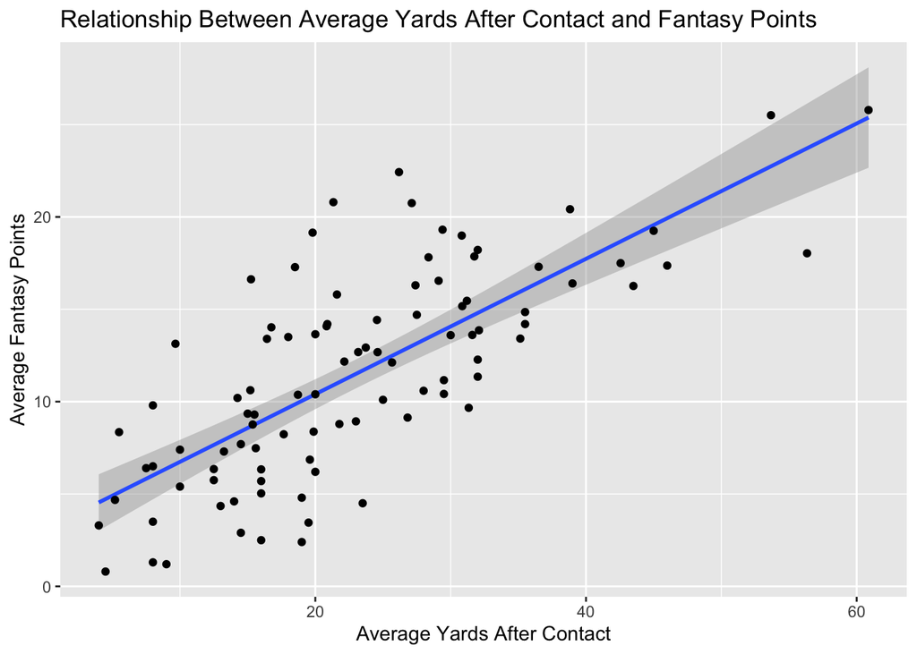

```r
RB_yac <- ggplot(RB_totals, aes(x = AVG_Yds_After_Contact, y = AVG_Total_DKP))+
  geom_smooth(method = "lm", se = TRUE)+
  labs(title = "Relationship Between Average Yards After Contact and Fantasy Points", x = "Average Yards After Contact", y = "Average Fantasy Points")+
  geom_point()
RB_yac
```

```r
RB_broken_tackles <- ggplot(RB_totals, aes(x = AVG_Broken_Tackles, y = AVG_Total_DKP))+
  geom_smooth(method = "lm", se = TRUE)+
  labs(title = "Relationship Between Average Broken Tackles and Fantasy Points", x = "Average Broken Tackles", y = "Average Fantasy Points")+
  geom_point()
```

### Now I Will Find Each Correlation for Each of These Stats in Relation to Fantasy Points:

```r
cor_avg_rush_att = corr(RB_totals$AVG_Rush_Att, RB_totals$AVG_Total_DKP)

cor_avg_rush_yds = corr(RB_totals$AVG_Rush_Yds, RB_totals$AVG_Total_DKP)

cor_avg_rush_td = corr(RB_totals$AVG_Rush_TD, RB_totals$AVG_Total_DKP)

cor_avg_rush_long = corr(RB_totals$AVG_Rush_Long, RB_totals$AVG_Total_DKP)

cor_avg_rb_targets = corr(RB_totals$AVG_Targets, RB_totals$AVG_Total_DKP)

cor_avg_rb_rec = corr(RB_totals$AVG_Rec, RB_totals$AVG_Total_DKP)

cor_avg_rb_rec_yds = corr(RB_totals$AVG_Receiving_Yards, RB_totals$AVG_Total_DKP)

cor_avg_rb_rec_td = corr(RB_totals$AVG_Receiving_TD, RB_totals$AVG_Total_DKP)

cor_avg_rb_yds_before_contact = corr(RB_totals$AVG_Yds_Before_Contact, RB_totals$AVG_Total_DKP)

cor_avg_rb_yds_after_contact = corr(RB_totals$AVG_Yds_After_Contact, RB_totals$AVG_Total_DKP)

cor_avg_rb_broken_tackles = corr(RB_totals$AVG_Broken_Tackles, RB_totals$AVG_Total_DKP)

RB_values = c(cor_avg_rush_att$estimate, cor_avg_rush_yds$estimate, cor_avg_rush_td$estimate, cor_avg_rush_long$estimate, cor_avg_rb_targets$estimate, cor_avg_rb_rec$estimate, cor_avg_rb_rec_yds$estimate, cor_avg_rb_rec_td$estimate, cor_avg_rb_yds_before_contact$estimate, cor_avg_rb_yds_after_contact$estimate, cor_avg_rb_broken_tackles$estimate)
row_names1 = c("Average Attempts", "Average Rushing Yards", "Average Rushing Touchdowns", "Average Longest Run", "Average Passing Targets", "Average Receptions", "Average Recieving Yards", "Average Recieving Touchdowns", "Average Yards Before Contact", "Average Yards After Contact", "Average Broken Tackles")
RB_table = data.frame(row_names1, RB_values)
RB_table = RB_table[order(RB_table$RB_values, decreasing = TRUE),]
RB_table
```

```
##                      row_names1 RB_values
## 2         Average Rushing Yards 0.7976372
## 7       Average Recieving Yards 0.7629032
## 6            Average Receptions 0.7517249
## 10  Average Yards After Contact 0.7387496
## 5       Average Passing Targets 0.7219403
## 9  Average Yards Before Contact 0.7184490
## 1              Average Attempts 0.6839729
## 3    Average Rushing Touchdowns 0.6288592
## 4           Average Longest Run 0.6273653
## 11       Average Broken Tackles 0.5616254
## 8  Average Recieving Touchdowns 0.4680772
```

### Next I Will Model the Stats With the Highest Correlations:

- Between the fantasy values, rushing yards, receiving yards, and receptions have the biggest correlation to fantasy points.

```r
model_rush_yds = lm(AVG_Total_DKP~AVG_Rush_Yds, RB_totals)
summary(model_rush_yds)
```

```
##
## Call:
## lm(formula = AVG_Total_DKP ~ AVG_Rush_Yds, data = RB_totals)
##
## Residuals:
##    Min     1Q Median     3Q    Max
## -6.283 -2.279 -0.928  2.475 10.595
##
## Coefficients:
##              Estimate Std. Error t value Pr(>|t|)
## (Intercept)   0.86256    0.90709   0.951    0.344
## AVG_Rush_Yds  0.21783    0.01708  12.754   <2e-16 ***
## ---
## Signif. codes:  0 '***' 0.001 '**' 0.01 '*' 0.05 '.' 0.1 ' ' 1
##
## Residual standard error: 3.439 on 93 degrees of freedom
## Multiple R-squared:  0.6362, Adjusted R-squared:  0.6323
## F-statistic: 162.7 on 1 and 93 DF,  p-value: < 2.2e-16
```

### This is the Linear Model for Rushing Yards and Fantasy Points:

- y = 0.2178x + 0.8626 R-Squared = 0.6323 (Slightly Above Average)

```r
model_receiving_yards_rb = lm(AVG_Total_DKP~AVG_Receiving_Yards, RB_totals)
summary(model_receiving_yards_rb)
```

```
##
## Call:
## lm(formula = AVG_Total_DKP ~ AVG_Receiving_Yards, data = RB_totals)
##
## Residuals:
##     Min      1Q  Median      3Q     Max
## -7.3084 -2.6325 -0.3575  2.1421 13.1407
##
## Coefficients:
##                     Estimate Std. Error t value Pr(>|t|)
## (Intercept)           6.0747     0.6099    9.96 2.49e-16 ***
## AVG_Receiving_Yards   0.3414     0.0300   11.38  < 2e-16 ***
## ---
## Signif. codes:  0 '***' 0.001 '**' 0.01 '*' 0.05 '.' 0.1 ' ' 1
##
## Residual standard error: 3.686 on 93 degrees of freedom
## Multiple R-squared:  0.582,  Adjusted R-squared:  0.5775
## F-statistic: 129.5 on 1 and 93 DF,  p-value: < 2.2e-16
```

### This is the Linear Model for Receiving Yards and Fantasy Points:

- y = 0.3414 + 6.0747 R-Squared = 0.5775 (Average)

```r
model_rec_rb = lm(AVG_Total_DKP~AVG_Rec, RB_totals)
summary(model_rec_rb)
```

```
##
## Call:
## lm(formula = AVG_Total_DKP ~ AVG_Rec, data = RB_totals)
##
## Residuals:
##    Min     1Q Median     3Q    Max
## -7.727 -2.642 -0.274  2.210 13.778
##
## Coefficients:
##             Estimate Std. Error t value Pr(>|t|)
## (Intercept)   5.3564     0.6806    7.87 6.33e-12 ***
## AVG_Rec       2.9568     0.2690   10.99  < 2e-16 ***
## ---
## Signif. codes:  0 '***' 0.001 '**' 0.01 '*' 0.05 '.' 0.1 ' ' 1
##
## Residual standard error: 3.76 on 93 degrees of freedom
## Multiple R-squared:  0.5651, Adjusted R-squared:  0.5604
## F-statistic: 120.8 on 1 and 93 DF,  p-value: < 2.2e-16
```

### This is the Linear Model for Catches and Fantasy Points:

- y = 2.9568x + 5.3564 R-Squared = 0.5604 (Average)

### Out of Non-Fantasy Stats, Yards After Contact, Before Contact, and Attempts:

```r
model_rush_before = lm(AVG_Total_DKP~AVG_Yds_Before_Contact, RB_totals)
summary(model_rush_before)
```

```
##
## Call:
## lm(formula = AVG_Total_DKP ~ AVG_Yds_Before_Contact, data = RB_totals)
##
## Residuals:
##     Min      1Q  Median      3Q     Max
## -9.1274 -2.8343 -0.5193  2.6859 10.8394
##
## Coefficients:
##                        Estimate Std. Error t value Pr(>|t|)
## (Intercept)             2.18656    1.02158   2.140   0.0349 *
## AVG_Yds_Before_Contact  0.36065    0.03621   9.961 2.48e-16 ***
## ---
## Signif. codes:  0 '***' 0.001 '**' 0.01 '*' 0.05 '.' 0.1 ' ' 1
##
## Residual standard error: 3.966 on 93 degrees of freedom
## Multiple R-squared:  0.5162, Adjusted R-squared:  0.511
## F-statistic: 99.22 on 1 and 93 DF,  p-value: 2.479e-16
```

### This is the Linear Model for Yards Before Contact and Fantasy Points:

- y = 0.3607x + 2.1866 R-Squared = 0.511 (Average)

```r
model_rush_after = lm(AVG_Total_DKP~AVG_Yds_After_Contact, RB_totals)
summary(model_rush_after)
```

```
##
## Call:
## lm(formula = AVG_Total_DKP ~ AVG_Yds_After_Contact, data = RB_totals)
##
## Residuals:
##     Min      1Q  Median      3Q     Max
## -7.6379 -2.5878 -0.3584  2.7851  9.9071
##
## Coefficients:
##                       Estimate Std. Error t value Pr(>|t|)
## (Intercept)            3.07624    0.89083   3.453 0.000836 ***
## AVG_Yds_After_Contact  0.36640    0.03466  10.570  < 2e-16 ***
## ---
## Signif. codes:  0 '***' 0.001 '**' 0.01 '*' 0.05 '.' 0.1 ' ' 1
##
## Residual standard error: 3.843 on 93 degrees of freedom
## Multiple R-squared:  0.5458, Adjusted R-squared:  0.5409
## F-statistic: 111.7 on 1 and 93 DF,  p-value: < 2.2e-16
```

### This is the Linear Model for Yards After Contact and Fantasy Points:

- y = 0.3664x + 3.0762 R-Squared = 0.5409 (Average)

```r
model_rush_att = lm(AVG_Total_DKP~AVG_Rush_Att, RB_totals)
summary(model_rush_att)
```

```
##
## Call:
## lm(formula = AVG_Total_DKP ~ AVG_Rush_Att, data = RB_totals)
##
## Residuals:
##     Min      1Q  Median      3Q     Max
## -9.4399 -2.5408 -0.5751  2.5571 11.2939
##
## Coefficients:
##              Estimate Std. Error t value Pr(>|t|)
## (Intercept)   -0.6459     1.4116  -0.458    0.648
## AVG_Rush_Att   1.0266     0.1135   9.042 2.18e-14 ***
## ---
## Signif. codes:  0 '***' 0.001 '**' 0.01 '*' 0.05 '.' 0.1 ' ' 1
##
## Residual standard error: 4.159 on 93 degrees of freedom
## Multiple R-squared:  0.4678, Adjusted R-squared:  0.4621
## F-statistic: 81.75 on 1 and 93 DF,  p-value: 2.179e-14
```

### This is the Linear Model for Rushing Attempts and Fantasy Points:

- y = 1.0266x - 0.6459 R-Squared = 0.4621 (Average)

### Finally I will Create The Data Frame For WR and TE Stats:

```r
WR_TE_df1 = sqldf("select pos, player, team, targets, rec, rec_yds, rec_td, rec_long,                         fumbles_lost, designed_rush_att, comb_pass_rush_play, comb_pass_play, Total_DKP
               from df
               where pos = 'WR' or pos = 'TE'")
WR_TE_totals = sqldf("select pos, player, team, avg(targets), avg(rec), avg(rec_yds),
                     avg(rec_td), avg(rec_long), avg(fumbles_lost), avg(designed_rush_att),
                     avg(comb_pass_rush_play), avg(comb_pass_play), avg(Total_DKP)
                     from WR_TE_df1
                     where targets > 2
                     group by player")
```

### Now I Will Rename All the WR and TE Columns so They Can be Used in SQL:

```r
WR_TE_totals = rename(WR_TE_totals, 'AVG_Total_DKP' = 'avg(Total_DKP)')
WR_TE_totals = rename(WR_TE_totals, 'AVG_Targets' = 'avg(targets)')
WR_TE_totals = rename(WR_TE_totals, 'AVG_Rec' = 'avg(rec)')
WR_TE_totals = rename(WR_TE_totals, 'AVG_Rec_Yds' = 'avg(rec_yds)')
WR_TE_totals = rename(WR_TE_totals, 'AVG_Rec_TD' = 'avg(rec_td)')
WR_TE_totals = rename(WR_TE_totals, 'AVG_Rec_Long' = 'avg(rec_long)')
WR_TE_totals = rename(WR_TE_totals, 'AVG_Rec_Passing_Rushing_Plays' = 'avg(comb_pass_rush_play)')
```

### Now I Will Graph the Statistics With the Strongest Relationship to Fantasy Points:

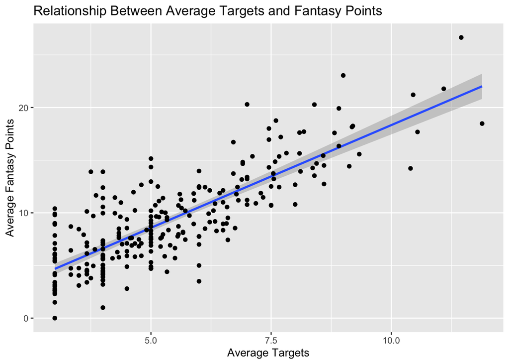

```r
WR_TE_targets <- ggplot(WR_TE_totals, aes(x = AVG_Targets, y = AVG_Total_DKP))+
  geom_smooth(method = "lm", se = TRUE)+
  labs(title = "Relationship Between Average Targets and Fantasy Points", x = "Average Targets", y = "Average Fantasy Points")+
  geom_point()
WR_TE_targets
```

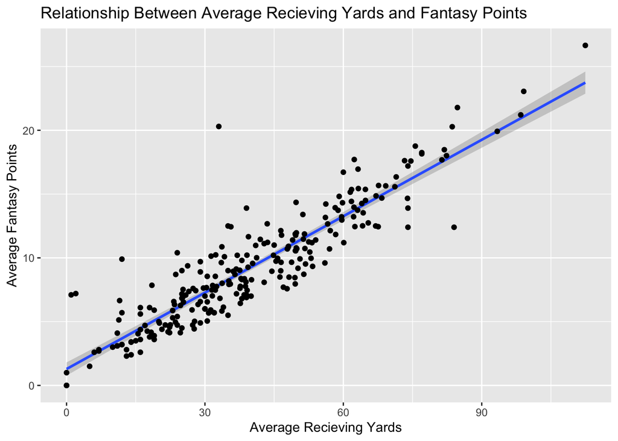

```r
WR_TE_rec <- ggplot(WR_TE_totals, aes(x = AVG_Rec, y = AVG_Total_DKP))+
  geom_smooth(method = "lm", se = TRUE)+
  labs(title = "Relationship Between Average Receptions and Fantasy Points", x = "Average Rec", y = "Average Fantasy Points")+
  geom_point()

WR_TE_rec_yds <- ggplot(WR_TE_totals, aes(x = AVG_Rec_Yds, y = AVG_Total_DKP))+
  geom_smooth(method = "lm", se = TRUE)+
  labs(title = "Relationship Between Average Recieving Yards and Fantasy Points", x = "Average Recieving Yards", y = "Average Fantasy Points")+
  geom_point()
WR_TE_rec_yds
```

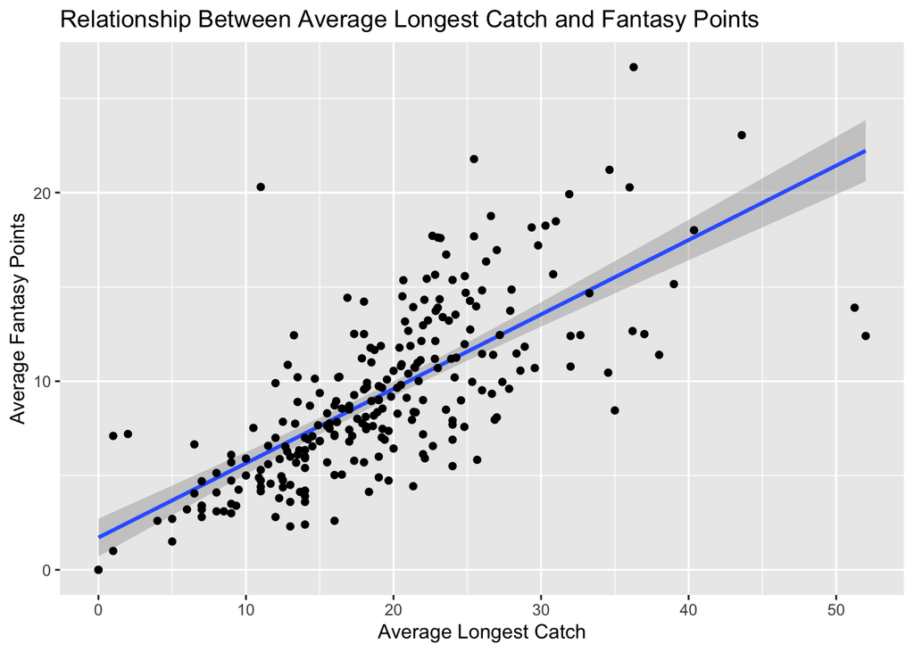

```r
WR_TE_rec_td <- ggplot(WR_TE_totals, aes(x = AVG_Rec_TD, y = AVG_Total_DKP))+
  geom_smooth(method = "lm", se = TRUE)+
  labs(title = "Relationship Between Average Recieving Touchdowns and Fantasy Points", x = "Average Recieving Touchdowns", y = "Average Fantasy Points")+
  geom_point()

WR_TE_rec_long <- ggplot(WR_TE_totals, aes(x = AVG_Rec_Long, y = AVG_Total_DKP))+
  geom_smooth(method = "lm", se = TRUE)+
  labs(title = "Relationship Between Average Longest Catch and Fantasy Points", x = "Average Longest Catch", y = "Average Fantasy Points")+
  geom_point()
WR_TE_rec_long
```

```r
WR_TE_passing_rushing_plays <- ggplot(WR_TE_totals, aes(x = AVG_Rec_Passing_Rushing_Plays, y = AVG_Total_DKP))+
  geom_smooth(method = "lm", se = TRUE)+
  labs(title = "Relationship Between Average Passing and Running Plays and Fantasy Points", x = "Average Passing and Running Plays", y = "Average Fantasy Points")+
  geom_point()
```

### I Will Now Find the Correlation for Each Statistic in Relation to Fantasy Points and Create a Table:

```r
cor_avg_targets = corr(WR_TE_totals$AVG_Targets, WR_TE_totals$AVG_Total_DK)

cor_avg_rec = corr(WR_TE_totals$AVG_Rec, WR_TE_totals$AVG_Total_DKP)

cor_avg_rec_yds = corr(WR_TE_totals$AVG_Rec_Yds, WR_TE_totals$AVG_Total_DKP)

cor_avg_td = corr(WR_TE_totals$AVG_Rec_TD, WR_TE_totals$AVG_Total_DKP)

cor_avg_rec_long = corr(WR_TE_totals$AVG_Rec_Long, WR_TE_totals$AVG_Total_DKP)

cor_avg_pass_rush_plays = corr(WR_TE_totals$AVG_Rec_Passing_Rushing_Plays, WR_TE_totals$AVG_Total_DKP)

WR_TE_values = c(cor_avg_targets$estimate, cor_avg_rec$estimate, cor_avg_rec_yds$estimate, cor_avg_td$estimate, cor_avg_rec_long$estimate, cor_avg_pass_rush_plays$estimate)
row_name = c("Average Targets", "Average Receptions", "Average Recieving Yards", "Averager Recieving Touchdowns", "Average Longest Catch", "Average Run and Pass Plays")
WR_TE_table = data.frame(row_name,WR_TE_values)
WR_TE_table = WR_TE_table[order(WR_TE_table$WR_TE_values, decreasing = TRUE),]
WR_TE_table
```

```
##                        row_name WR_TE_values
## 3       Average Recieving Yards    0.9065176
## 2            Average Receptions    0.8496987
## 1               Average Targets    0.8073433
## 5         Average Longest Catch    0.7132301
## 4 Averager Recieving Touchdowns    0.6500585
## 6    Average Run and Pass Plays    0.1365477
```

### Now we Will Model The Statistics With the Highest Correlations:

- The Fantasy Statistic With the Highest Correlation is Receiving Yards .

```r
model_for_rec_yds_wr_te = lm(AVG_Total_DKP~AVG_Rec_Yds, WR_TE_totals)
summary(model_for_rec_yds_wr_te)
```

```
##
## Call:
## lm(formula = AVG_Total_DKP ~ AVG_Rec_Yds, data = WR_TE_totals)
##
## Residuals:
##     Min      1Q  Median      3Q     Max
## -5.6574 -1.2725 -0.2365  0.8408 12.4250
##
## Coefficients:
##             Estimate Std. Error t value Pr(>|t|)
## (Intercept) 1.286414   0.263472   4.883 1.86e-06 ***
## AVG_Rec_Yds 0.199654   0.005857  34.087  < 2e-16 ***
## ---
## Signif. codes:  0 '***' 0.001 '**' 0.01 '*' 0.05 '.' 0.1 ' ' 1
##
## Residual standard error: 1.906 on 252 degrees of freedom
## Multiple R-squared:  0.8218, Adjusted R-squared:  0.8211
## F-statistic:  1162 on 1 and 252 DF,  p-value: < 2.2e-16
```

### This is the Linear Model for Receiving Yards and Fantasy Points:

- y = 0.1997x + 1.2864 R-Squared = 0.8211 (Good)
- Some non-calculated stats to consider are targets and longest catch.

```r
model_for_target_wr_te = lm(AVG_Total_DKP~AVG_Targets, WR_TE_totals)
summary(model_for_target_wr_te)
```

```
##
## Call:
## lm(formula = AVG_Total_DKP ~ AVG_Targets, data = WR_TE_totals)
##
## Residuals:
##     Min      1Q  Median      3Q     Max
## -7.0300 -1.7669 -0.5047  1.4713  7.8193
##
## Coefficients:
##             Estimate Std. Error t value Pr(>|t|)
## (Intercept) -1.17380    0.50990  -2.302   0.0221 *
## AVG_Targets  1.95064    0.08981  21.719   <2e-16 ***
## ---
## Signif. codes:  0 '***' 0.001 '**' 0.01 '*' 0.05 '.' 0.1 ' ' 1
##
## Residual standard error: 2.664 on 252 degrees of freedom
## Multiple R-squared:  0.6518, Adjusted R-squared:  0.6504
## F-statistic: 471.7 on 1 and 252 DF,  p-value: < 2.2e-16
```

### This is the Linear Model for Targets and Fantasy Points:

- y = 1.9506x -1.1738 R-Squared = 0.6518 (Above Average)

```r
model_long_rec_wr_te = lm(AVG_Total_DKP~AVG_Rec_Long, WR_TE_totals)
summary(model_long_rec_wr_te)
```

```
##
## Call:
## lm(formula = AVG_Total_DKP ~ AVG_Rec_Long, data = WR_TE_totals)
##
## Residuals:
##    Min     1Q Median     3Q    Max
## -9.821 -1.872 -0.399  1.818 14.251
##
## Coefficients:
##              Estimate Std. Error t value Pr(>|t|)
## (Intercept)   1.71044    0.50945   3.357 0.000908 ***
## AVG_Rec_Long  0.39444    0.02442  16.153  < 2e-16 ***
## ---
## Signif. codes:  0 '***' 0.001 '**' 0.01 '*' 0.05 '.' 0.1 ' ' 1
##
## Residual standard error: 3.165 on 252 degrees of freedom
## Multiple R-squared:  0.5087, Adjusted R-squared:  0.5067
## F-statistic: 260.9 on 1 and 252 DF,  p-value: < 2.2e-16
```

### This is the Linear Model for Longest Catch and Fantasy Points:

- y = 0.3944x + 1.7104 R-Squared = 0.5067 (Average)

## Part 2 Conclusion:

When selecting a fantasy team:

At QB use:

- y = 7.2347x + 6.9655 where x is the number of passing touchdowns.
- This is the model that is most likely to give an accurate estimate.
- To have an extra advantage on your opponents you can use y = 0.2676x -6.6782, where x is passer rating

At RB, the most reliable model is:

- y = 0.2178x + 0.8626, where x is rushing yards
- For an extra advantage you should look for physical runners who gain a lot of yards after contact
- To predict their points you can use y = 0.3664x + 3.0762 where x is yards after contact

Overall this project should help fantasy players look for which specific stats can help them select players who will put up good fantasy points in the future.

### Next Steps:

- The next step would be to try and make predictions for the future based off these models and team rankings.